# Project1:

# Investigate Environmental datasets

*CO<sub>2</sub> emission*\ *Forest area*\ *Natural gas production*\ *Sustainable Development Index*

- Introduction
- Questions
- Data Wrangling
- Exploratory Data Analysis
- Conclusions
- Limitation

## Introduction

### Dataset Description

The environmental data used in this project comes from [Gapminder](https://www.gapminder.org/data/).\ The platform Gapminder has collected a lot of information about how people live their lives in different countries, tracked across the years, and on a number of different indicators. We have selected 4 variables of interest which are time series for our study.

**CO<sub>2</sub> emission**\ This data represents Carbon dioxide emissions from the burning of fossil fuels (Unit: metric tonnes of CO<sub>2</sub> per personn).

**Forest area**\ This dataset represent land under natural or planted stands of trees of at least 5 meters in situ, whether productive or not, and excludes tree stands in agricultural production systems (Unit: sq.km).

**Natural gas production** \ Conventional Natural Gas Production Natural gas is primarily extracted from gas and oil wells. (Unit: tons oil equivalent).

**Sustainable Development Index** \ The Sustainable Development Index is an efficiency metric, designed to assess the ecological efficiency of nations in delivering human development.\ It is calculated as the quotient of two figures:

- a “development index” based on the Human Development Index, calculated as the geometric mean of the life expectancy index, the education index, and a modified income index;
- an “ecological impact index” calculated as the extent to which consumption-based CO<sub>2</sub> emissions and material footprint exceed per-capita shares of planetary boundaries.

## Questions

1. What are the average dynamics of CO<sub>2</sub> emissions, the state of forest cover, natural gas, and the Sustainable Development Index?\

   ```
    a) What can we learn from the dynamics of these variables at the global level?\
    b) Is there a relation between forest decrease and natural gas production?
   ```

2. Analyze the 10 countries which had the largest forest cover and the highest natural gas production in 2018.\ a) In 2018, which 10 countries had the largest forest cover and the highest natural gas production?\ b) Which countries are on both lists of largest forest cover and the highest natural gas production in 2018?
3. Natural gas production by African countries.\ a) How many and which African countries have produced natural gas?\ b) What is the dynamics of their production? Which country produces the most? Which is the lowest producer?
4. The Sustainable Development Index (SDI) measures the ecological efficiency of nations in terms of human development.\ a) Is there a link between each of these 3 variables and the sustainable development index?

```python
#import all packages needed
import os
import numpy as np
import pandas as pd
import matplotlib.pyplot as plt
import seaborn as sns
from scipy import stats
import warnings
warnings.filterwarnings("ignore")
```

## Data Wrangling

In this part, we will define functions and perform data cleaning, selection and data combination operations

```python
### define function to set up the path of environment

def set_path (path=None):
    """
    Define the path of your files with this function. This function  help you to avoid writing long paths to files (dataset)
    when reading by pandas especially when your datasets are not in the same folder as your notebook.
    Parameters:
    path : directory of the .csv files

    """
    if path == None:
        print("Path is not written, please set up the directory of your files!")
    else:
        os.chdir(path)
        print("****CSV files present in your directory****")
        for files in os.listdir():
            if files.endswith('.csv'):
                print(files)
```

We change our working directory and datasets loading

```python
### Change my working directory
set_path(path = "D:\Python_Project\ALTx")
```

```
****CSV files present in your directory****
africa_country.csv
biomass_stock_in_forest_tons.csv
co2_emissions_tonnes_per_person.csv
Countries-Continents.csv
forest_area_sq_km.csv
natural_gas_production_total.csv
population_total.csv
sdi.csv
```

```python
#load all datasets
df_co2_emission = pd.read_csv("co2_emissions_tonnes_per_person.csv")
df_forest_area = pd.read_csv("forest_area_sq_km.csv")
df_sustainable_index = pd.read_csv("sdi.csv")
df_gas = pd.read_csv("natural_gas_production_total.csv")
```

#### *Datasets checking*

```python
#Display first 4 line of dataset
df_co2_emission.head(4)
```

|  | country | 1800 | 1801 | 1802 | 1803 | 1804 | 1805 | 1806 | 1807 | 1808 | ... | 2009 | 2010 | 2011 | 2012 | 2013 | 2014 | 2015 | 2016 | 2017 | 2018 |
| --- | --- | --- | --- | --- | --- | --- | --- | --- | --- | --- | --- | --- | --- | --- | --- | --- | --- | --- | --- | --- | --- |
| 0 | Afghanistan | NaN | NaN | NaN | NaN | NaN | NaN | NaN | NaN | NaN | ... | 0.238 | 0.29 | 0.406 | 0.345 | 0.28 | 0.253 | 0.262 | 0.245 | 0.247 | 0.254 |
| 1 | Angola | NaN | NaN | NaN | NaN | NaN | NaN | NaN | NaN | NaN | ... | 1.230 | 1.24 | 1.250 | 1.350 | 1.28 | 1.640 | 1.220 | 1.180 | 1.140 | 1.120 |
| 2 | Albania | NaN | NaN | NaN | NaN | NaN | NaN | NaN | NaN | NaN | ... | 1.470 | 1.56 | 1.790 | 1.690 | 1.69 | 1.900 | 1.600 | 1.570 | 1.610 | 1.590 |
| 3 | Andorra | NaN | NaN | NaN | NaN | NaN | NaN | NaN | NaN | NaN | ... | 6.120 | 6.12 | 5.870 | 5.920 | 5.90 | 5.830 | 5.970 | 6.070 | 6.270 | 6.120 |

4 rows × 220 columns

```python
##Display informations of dataset elements
df_co2_emission.info(max_cols=300)
```

```
<class 'pandas.core.frame.DataFrame'>
RangeIndex: 194 entries, 0 to 193
Data columns (total 220 columns):
 #    Column   Non-Null Count  Dtype
---   ------   --------------  -----
 0    country  194 non-null    object
 1    1800     5 non-null      float64
 2    1801     5 non-null      float64
 3    1802     7 non-null      float64
 4    1803     5 non-null      float64
 5    1804     6 non-null      float64
 6    1805     5 non-null      float64
 7    1806     5 non-null      float64
 8    1807     6 non-null      float64
 9    1808     5 non-null      float64
```

[output cut: 212 more lines]

```python
#Display first 4 line of dataset
df_forest_area.head(4)
```

|  | country | 1990 | 1991 | 1992 | 1993 | 1994 | 1995 | 1996 | 1997 | 1998 | ... | 2011 | 2012 | 2013 | 2014 | 2015 | 2016 | 2017 | 2018 | 2019 | 2020 |
| --- | --- | --- | --- | --- | --- | --- | --- | --- | --- | --- | --- | --- | --- | --- | --- | --- | --- | --- | --- | --- | --- |
| 0 | Aruba | 4.2 | 4.2 | 4.2 | 4.2 | 4.2 | 4.2 | 4.2 | 4.2 | 4.2 | ... | 4.2 | 4.2 | 4.2 | 4.2 | 4.2 | 4.2 | 4.2 | 4.2 | 4.2 | 4.2 |
| 1 | Afghanistan | 12.1k | 12.1k | 12.1k | 12.1k | 12.1k | 12.1k | 12.1k | 12.1k | 12.1k | ... | 12.1k | 12.1k | 12.1k | 12.1k | 12.1k | 12.1k | 12.1k | 12.1k | 12.1k | 12.1k |
| 2 | Angola | 793k | 791k | 790k | 788k | 786k | 785k | 783k | 782k | 780k | ... | 716k | 710k | 705k | 699k | 694k | 688k | 683k | 677k | 672k | 666k |
| 3 | Albania | 7890 | 7870 | 7850 | 7830 | 7810 | 7790 | 7770 | 7750 | 7730 | ... | 7830 | 7850 | 7860 | 7880 | 7890 | 7890 | 7890 | 7890 | 7890 | 7890 |

4 rows × 32 columns

```python
##Display informations of dataset elements
df_forest_area.info()
```

```
<class 'pandas.core.frame.DataFrame'>
RangeIndex: 214 entries, 0 to 213
Data columns (total 32 columns):
 #   Column   Non-Null Count  Dtype
---  ------   --------------  -----
 0   country  214 non-null    object
 1   1990     210 non-null    object
 2   1991     210 non-null    object
 3   1992     210 non-null    object
 4   1993     210 non-null    object
 5   1994     210 non-null    object
 6   1995     210 non-null    object
 7   1996     210 non-null    object
 8   1997     210 non-null    object
 9   1998     210 non-null    object
```

[output cut: 24 more lines]

```python
#Display first 4 line of dataset
df_sustainable_index.head(4)
```

|  | country | 1990 | 1991 | 1992 | 1993 | 1994 | 1995 | 1996 | 1997 | 1998 | ... | 2010 | 2011 | 2012 | 2013 | 2014 | 2015 | 2016 | 2017 | 2018 | 2019 |
| --- | --- | --- | --- | --- | --- | --- | --- | --- | --- | --- | --- | --- | --- | --- | --- | --- | --- | --- | --- | --- | --- |
| 0 | Afghanistan | 32.5 | 33.1 | 34.0 | 33.5 | 33.0 | 35.6 | 36.0 | 36.6 | 37.1 | ... | 50.8 | 51.4 | 52.7 | 53.4 | 53.8 | 53.8 | 54.1 | 54.5 | 54.9 | 55.1 |
| 1 | Angola | NaN | NaN | NaN | NaN | NaN | NaN | NaN | NaN | NaN | ... | 55.8 | 57.4 | 58.6 | 59.8 | 60.8 | 61.6 | 62.2 | 62.7 | 62.7 | 62.6 |
| 2 | Albania | 69.9 | 68.0 | 66.2 | 66.5 | 67.2 | 68.6 | 69.5 | 69.5 | 70.6 | ... | 79.6 | 81.1 | 82.2 | 82.6 | 82.6 | 82.3 | 82.1 | 82.1 | 82.3 | 82.6 |
| 3 | United Arab Emirates | 46.9 | 29.2 | 19.4 | 12.8 | 10.6 | 11.1 | 9.9 | 10.2 | 10.7 | ... | 14.7 | 13.6 | 13.2 | 11.9 | 11.5 | 11.0 | 10.8 | 10.9 | 11.0 | 11.0 |

4 rows × 31 columns

```python
##Display informations of dataset elements
df_sustainable_index.info()
```

```
<class 'pandas.core.frame.DataFrame'>
RangeIndex: 164 entries, 0 to 163
Data columns (total 31 columns):
 #   Column   Non-Null Count  Dtype
---  ------   --------------  -----
 0   country  164 non-null    object
 1   1990     129 non-null    float64
 2   1991     137 non-null    float64
 3   1992     137 non-null    float64
 4   1993     138 non-null    float64
 5   1994     138 non-null    float64
 6   1995     141 non-null    float64
 7   1996     141 non-null    float64
 8   1997     141 non-null    float64
 9   1998     141 non-null    float64
```

[output cut: 23 more lines]

```python
#Display first 4 line of dataset
df_gas.head(4)
```

|  | country | 1970 | 1971 | 1972 | 1973 | 1974 | 1975 | 1976 | 1977 | 1978 | ... | 2010 | 2011 | 2012 | 2013 | 2014 | 2015 | 2016 | 2017 | 2018 | 2019 |
| --- | --- | --- | --- | --- | --- | --- | --- | --- | --- | --- | --- | --- | --- | --- | --- | --- | --- | --- | --- | --- | --- |
| 0 | United Arab Emirates | 698k | 1.23M | 1.25M | 1.45M | 1.46M | 1.39M | 1.63M | 3.27M | 4.79M | ... | 43M | 43.9M | 45.5M | 45.8M | 45.5M | 50.5M | 51.9M | 53.6M | 52.8M | 53.8M |
| 1 | Argentina | 5.03M | 5.44M | 5.17M | 5.63M | 6.06M | 6.43M | 6.13M | 6.33M | 6.53M | ... | 33.5M | 32.4M | 31.5M | 29.7M | 29.7M | 30.5M | 32.1M | 31.9M | 33.9M | 35.8M |
| 2 | Australia | 1.49M | 2.22M | 3.19M | 4.05M | 4.62M | 4.96M | 5.85M | 6.69M | 7.2M | ... | 46.4M | 47.9M | 51.2M | 53.1M | 57.3M | 65.4M | 82.9M | 97M | 112M | 132M |
| 3 | Azerbaijan | NaN | NaN | NaN | NaN | NaN | NaN | NaN | NaN | NaN | ... | 14M | 13.7M | 14.5M | 15M | 15.8M | 16.2M | 15.7M | 15.3M | 16.4M | 20.9M |

4 rows × 51 columns

```python
##Display informations of dataset elements
df_gas.info()
```

```
<class 'pandas.core.frame.DataFrame'>
RangeIndex: 50 entries, 0 to 49
Data columns (total 51 columns):
 #   Column   Non-Null Count  Dtype
---  ------   --------------  -----
 0   country  50 non-null     object
 1   1970     44 non-null     object
 2   1971     44 non-null     object
 3   1972     44 non-null     object
 4   1973     44 non-null     object
 5   1974     44 non-null     object
 6   1975     44 non-null     object
 7   1976     44 non-null     object
 8   1977     44 non-null     object
 9   1978     44 non-null     object
```

[output cut: 43 more lines]

```python
## Function to get dataframe's shape
def shape_function(list_dataframe, name_dataframe):
    """
    This function print the number of columns and rows of your datasets

    Parameters:
    list_dataframe: list of dataframe you have created.
    name_dataframe: list of your dataframe's name

    """
    if not (isinstance(list_dataframe, list) and isinstance(name_dataframe, list)):
        print("ERROR: All your Parameters must be a list.")
    else:
        if len(list_dataframe) != len(name_dataframe):
            print("ERROR: Length of Parameters must be same.")
        else:
            i = 0
            for ds in list_dataframe:
                print(f"The {name_dataframe[i]} dataset contains {ds.shape[1]} columns and {ds.shape[0]} rows.")
                i +=1
```

```python
#This code give the shape of dataset
#by using previous shape_function
list_dataset = [df_co2_emission, df_forest_area, df_gas, df_sustainable_index]
list_name_dataset = ["CO2_emission", "forest_area", "natural_gas", "sustainable_index"]
shape_function(list_dataset, list_name_dataset)
```

```
The CO2_emission dataset contains 220 columns and 194 rows.
The forest_area dataset contains 32 columns and 214 rows.
The natural_gas dataset contains 51 columns and 50 rows.
The sustainable_index dataset contains 31 columns and 164 rows.
```

```python
#Concatenate all the 4 dataframe into final one.
#by using pd.concat
df_co2_20year = pd.concat([df_co2_emission.iloc[:,:1], df_co2_emission.iloc[:,-20:]],axis = 1)
df_forest_20year = pd.concat([df_forest_area.iloc[:,:1], df_forest_area.iloc[:,-20:]],axis = 1)
df_gas_20year = pd.concat([df_gas.iloc[:,:1], df_gas.iloc[:,-20:]],axis = 1)
df_sdi_20year = pd.concat([df_sustainable_index.iloc[:,:1], df_sustainable_index.iloc[1:,-20:]],axis = 1)
```

```python
#Check the shape for the final dataset
shape_function([df_co2_20year, df_forest_20year, df_gas_20year, df_sdi_20year], list_name_dataset)
```

```
The CO2_emission dataset contains 21 columns and 194 rows.
The forest_area dataset contains 21 columns and 214 rows.
The natural_gas dataset contains 21 columns and 50 rows.
The sustainable_index dataset contains 21 columns and 164 rows.
```

**Here we have 21 columns (20 years and country columns)**

#### *Data cleaning*

In this section, we pivot the data, then decode some of the columns, merge all the datasets and perform some analysis of the dataset distributions.

```python
### Melt dataset function

def melt_function(data, name_value):

    """
    This function print the number of columns and rows of your datasets

    Parameters:
    data: dataframe to melt
    name_value: customize value output

    """
    ls_cols = data.columns.to_list()[1:]

    return data.melt(id_vars=['country'], value_vars=ls_cols, var_name='year', value_name=name_value)
```

```python
###decode function

def decode_rows(data, col):

    """
    This function extrat and convert each row from object dtype to numerical by decoding:
    code: B, M, K respectively for Billion, Million and Thousand
    e.g : 81.2M = 81.2x10E6, 81.2B = 81.2x10E9

    Parameters:
    data: dataframe
    col: column of interest

    """
    if data[col].dtypes == 'float' or data[col].dtypes == 'int':

        #print(f"You don't need to decode this columns. The type of {col} is {data[col].dtypes}.")

        return data

    else:


        extract_data = data[col].str.extract(r'(?P<digit>[\d\.\d]+)')
        extract_data["letter"] = data[col].str.extract('([a-zA-Z ]+)')

        if extract_data.digit.dtypes != 'float':
            extract_data.digit = extract_data.digit.astype(float)

        extract_data.letter = extract_data.letter.apply(lambda x: 1000000000 if str(x).startswith('B') \
                                                        else (1000000 if str(x).startswith('M') \
                                                              else (1000 if str(x).startswith('k') else 1)))

        data[col] = extract_data["digit"]*extract_data["letter"]

        return data
```

```python
#Applying mel_function and decode_rows functions
ref_natural_gas = decode_rows(melt_function(df_gas_20year, "natural_gas"), "natural_gas")
ref_co2 = decode_rows(melt_function(df_co2_20year, "CO2_emission"), "CO2_emission")
ref_forest = decode_rows(melt_function(df_forest_20year, "forest_area"), "forest_area")
ref_sdi = decode_rows(melt_function(df_sdi_20year, "sustainable"), "sustainable")
```

```python
###Merge all datasets in one
dfs = [ref_natural_gas, ref_co2, ref_forest, ref_sdi]
import functools as ft
df_final = ft.reduce(lambda left, right: pd.merge(left, right, on=['country', 'year'], how='outer'), dfs)
```

##### Preliminary Checking

```python
#display all informations about this dataset
df_final.info()
```

```
<class 'pandas.core.frame.DataFrame'>
Int64Index: 4724 entries, 0 to 4723
Data columns (total 6 columns):
 #   Column        Non-Null Count  Dtype
---  ------        --------------  -----
 0   country       4724 non-null   object
 1   year          4724 non-null   object
 2   natural_gas   980 non-null    float64
 3   CO2_emission  3877 non-null   float64
 4   forest_area   4236 non-null   float64
 5   sustainable   3205 non-null   float64
dtypes: float64(4), object(2)
memory usage: 258.3+ KB
```

```python
#display the 5 first element
df_final.head()
```

|  | country | year | natural_gas | CO2_emission | forest_area | sustainable |
| --- | --- | --- | --- | --- | --- | --- |
| 0 | United Arab Emirates | 2000 | 32200000.0 | 35.700 | NaN | 10.5 |
| 1 | Argentina | 2000 | 31300000.0 | 3.850 | NaN | 80.3 |
| 2 | Australia | 2000 | 26800000.0 | 18.500 | NaN | 24.3 |
| 3 | Azerbaijan | 2000 | 4420000.0 | 3.640 | NaN | 68.2 |
| 4 | Bangladesh | 2000 | 7790000.0 | 0.208 | NaN | 51.4 |

```python
#Basy stats of variable
df_final.describe()
```

|  | natural_gas | CO2_emission | forest_area | sustainable |
| --- | --- | --- | --- | --- |
| count | 9.800000e+02 | 3877.000000 | 4.236000e+03 | 3205.000000 |
| mean | 5.367411e+07 | 4.655918 | 1.928004e+05 | 56.704524 |
| std | 1.037206e+08 | 6.316335 | 7.533041e+05 | 17.437258 |
| min | 0.000000e+00 | 0.015900 | 0.000000e+00 | 7.900000 |
| 25% | 9.692500e+06 | 0.613000 | 1.380000e+03 | 45.400000 |
| 50% | 2.415000e+07 | 2.350000 | 2.040000e+04 | 58.600000 |
| 75% | 5.070000e+07 | 6.520000 | 9.850000e+04 | 71.700000 |
| max | 7.920000e+08 | 67.100000 | 8.150000e+06 | 85.300000 |

```python
#display total of unique value of year and country in the dataframe
df_final.year.nunique(), df_final.country.nunique()
```

```
(22, 217)
```

```python
#Check duplicate rows
df_final.duplicated().sum()
```

```
0
```

```python
#Check nan value in the rows
df_final.isna().sum()
```

```
country            0
year               0
natural_gas     3744
CO2_emission     847
forest_area      488
sustainable     1519
dtype: int64
```

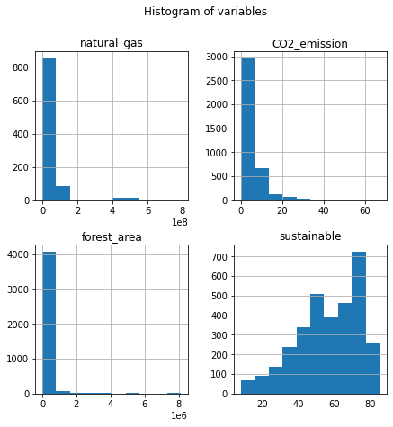

```python
#Histogramm plot
df_final.hist(figsize=(7,7));
plt.suptitle("Histogram of variables")
plt.show()
```

```python
#Display distribustion stats of dataset
# Skewness and kurtosis stats
def distribution_stats(data, columns):
    from scipy import stats

    #loop to calculate stats parameters
    for col in columns:
        sk = stats.skew(data[col].dropna(), bias=False)
        kurt = stats.kurtosis(data[col].dropna(), bias=False)
        #Check and print conclusion depend on stats parameters value

        skew_comparison = lambda x : "asymmetrical to the right" if  x > 0 else ("normal and symmetric"
                                                                                 if x==0 else "asymmetrical to the left")

        kurtosis_comparison = lambda y : "sharp (leptokurtotic)" if  y > 3 else ("normal"
                                                                                 if y==3 else "crushed (playkurtotic)")

        print(f"The skew value of {col} is equal to {round(sk, 2)}. The distribuion is therefore {skew_comparison(sk)}.")
        print(f"The kurtosis value of {col} is equal to {round(kurt, 2)}. The distribuion is therefore {kurtosis_comparison(kurt)}.")
        print("")
        print("=======================================================================================================")
```

```python
#Apply disdistribution_stats to my dataset
cols = ['natural_gas', 'CO2_emission', 'forest_area', 'sustainable']
distribution_stats(df_final, cols)
```

```
The skew value of natural_gas is equal to 4.1. The distribuion is therefore asymmetrical to the right.
The kurtosis value of natural_gas is equal to 17.46. The distribuion is therefore sharp (leptokurtotic).

=======================================================================================================
The skew value of CO2_emission is equal to 3.35. The distribuion is therefore asymmetrical to the right.
The kurtosis value of CO2_emission is equal to 18.2. The distribuion is therefore sharp (leptokurtotic).

=======================================================================================================
The skew value of forest_area is equal to 7.66. The distribuion is therefore asymmetrical to the right.
The kurtosis value of forest_area is equal to 67.46. The distribuion is therefore sharp (leptokurtotic).

=======================================================================================================
The skew value of sustainable is equal to -0.6. The distribuion is therefore asymmetrical to the left.
The kurtosis value of sustainable is equal to -0.39. The distribuion is therefore crushed (playkurtotic).

=======================================================================================================
```

**There is no variable in the dataset that is normally distributed.**

## Exploratory Data Analysis

#### Research Questions

1. What are the average dynamics of CO<sub>2</sub> emissions, the state of forest cover, natural gas, and the Sustainable Development Index?\ a) What can we learn from the dynamics of these variables at the global level?\ b) Is there a relation between forest decrease and natural gas production?
2. Analyze the 10 countries which had the largest forest cover and the highest natural gas production in 2018.\ a) In 2018, which 10 countries had the largest forest cover and the highest natural gas production?\ b) Which countries are on both lists of largest forest cover and the highest natural gas production in 2018?
3. Natural gas production by African countries.\ a) How many and which African countries have produced natural gas?\ b) What is the dynamics of their production? Which country produces the most? Which is the lowest producer?
4. The Sustainable Development Index (SDI) measures the ecological efficiency of nations in terms of human development.\ a) Is there a link between each of these 3 variables and the sustainable development index?

#### 1. What are the average dynamics of CO<sub>2</sub> emissions, the state of forest cover, natural gas, and the Sustainable Development Index?

##### a) What can we learn from the dynamics of these variables at the global level?

```python
#Transform year in index for plot purpose
df_final = df_final.set_index("year")
```

```python
cols
```

```
['natural_gas', 'CO2_emission', 'forest_area', 'sustainable']
```

```python
#Group by year
avg = df_final.groupby(["year"]).mean()
```

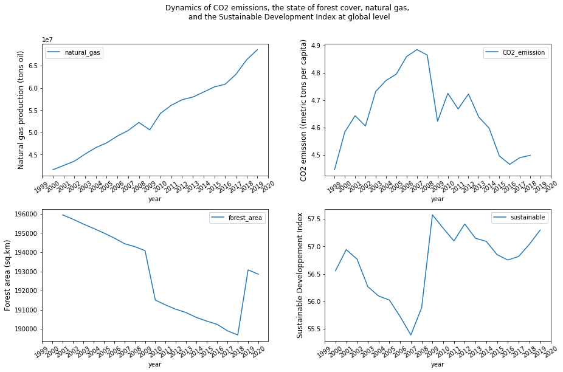

```python
#Plot the average of each variables
labels = ['Natural gas production (tons oil)', 'CO2 emission ((metric tons per capita)',
          'Forest area (sq.km)', 'Sustainable Developpement Index']
plt.figure(figsize=(15, 9))
plt.subplots_adjust(wspace=0.25, hspace=0.25)

j=0
for i in range(1, 5):

    plt.subplot(2, 2, i)

    avg[cols[j]].plot()
    plt.xlabel("year")
    plt.ylabel(labels[j], size=12)
    plt.xticks(list(range(0,22)), avg.index.to_list(), rotation='35')
    plt.legend()
    j+=1


plt.suptitle("Dynamics of CO2 emissions, the state of forest cover, natural gas, \n and the Sustainable Development Index at global level")

plt.show()
```

##### b) Is there a relation between forest decrease and natural gas production?

```python
#calculate Rsquare for correlation

x=avg.natural_gas.dropna()
y=avg.forest_area.dropna()
pr = stats.pearsonr(x, y)[0]
print("R² =", round(pr,2))
```

```
R² = -0.75
```

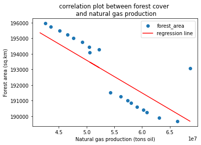

```python
#correlation plot
plt.scatter(x="natural_gas", y="forest_area", data=avg) #add scatter plot

#find line of best fit
a, b = np.polyfit(x, y, 1)

#add line of best fit to plot
plt.plot(x, a*x+b, color="red", label="regression line")
plt.legend()
plt.xlabel("Natural gas production (tons oil)")
plt.ylabel("Forest area (sq.km)")
plt.title("correlation plot between forest cover \n and natural gas production")
plt.show()
```

It is suggested that as natural gas production increases, the area of forest decreases.\ The Pearson correlation coefficient is -0.75.

#### 2. Analyze the 10 countries which had the largest forest cover and the highest natural gas production in 2018.

##### a) In 2018, which 10 countries had the largest forest cover and the highest natural gas production?

```python
#Reset index
df_final.reset_index(inplace=True)
```

```python
#Extract year == 2018
df_final_2018 = df_final[df_final["year"] == '2018']
```

```python
#Sort the dataset
forest_10y = df_final_2018.sort_values(by=['forest_area'], ascending=False).iloc[:10]
forest_10y
```

|  | year | country | natural_gas | CO2_emission | forest_area | sustainable |
| --- | --- | --- | --- | --- | --- | --- |
| 937 | 2018 | Russia | 575000000.0 | 11.7000 | 8150000.0 | 68.4 |
| 907 | 2018 | Brazil | 21600000.0 | 2.1800 | 4990000.0 | 75.1 |
| 909 | 2018 | Canada | 154000000.0 | 15.3000 | 3470000.0 | 19.1 |
| 944 | 2018 | United States | 719000000.0 | 16.6000 | 3100000.0 | 18.1 |
| 910 | 2018 | China | 139000000.0 | 7.0600 | 2160000.0 | 51.3 |
| 902 | 2018 | Australia | 112000000.0 | 16.9000 | 1340000.0 | 15.0 |
| 3828 | 2018 | Congo, Dem. Rep. | NaN | 0.0243 | 1280000.0 | 51.5 |
| 917 | 2018 | Indonesia | 62600000.0 | 2.3000 | 933000.0 | 76.5 |
| 933 | 2018 | Peru | 11000000.0 | 1.7400 | 727000.0 | 81.2 |
| 918 | 2018 | India | 23600000.0 | 1.9600 | 716000.0 | 69.1 |

In 2018, it is Russia, Brazil, Canada, United States, China, Australia, DR Congo, Indonesia, Peru, and India have the most important forest areas.

```python
#Sort the dataset
natural_10y = df_final_2018.sort_values(by=['natural_gas'], ascending=False).iloc[:10]
natural_10y
```

|  | year | country | natural_gas | CO2_emission | forest_area | sustainable |
| --- | --- | --- | --- | --- | --- | --- |
| 944 | 2018 | United States | 719000000.0 | 16.60 | 3100000.0 | 18.1 |
| 937 | 2018 | Russia | 575000000.0 | 11.70 | 8150000.0 | 68.4 |
| 919 | 2018 | Iran | 205000000.0 | 8.81 | 107000.0 | 61.3 |
| 909 | 2018 | Canada | 154000000.0 | 15.30 | 3470000.0 | 19.1 |
| 935 | 2018 | Qatar | 152000000.0 | 38.00 | 0.0 | 25.9 |
| 910 | 2018 | China | 139000000.0 | 7.06 | 2160000.0 | 51.3 |
| 902 | 2018 | Australia | 112000000.0 | 16.90 | 1340000.0 | 15.0 |
| 930 | 2018 | Norway | 104000000.0 | 8.31 | 122000.0 | 19.7 |
| 938 | 2018 | Saudi Arabia | 96400000.0 | 18.40 | 9770.0 | 45.6 |
| 914 | 2018 | Algeria | 80700000.0 | 3.69 | 19300.0 | 80.1 |

In 2018, it is Russia, Canada, United States, China, Qatar, Iran, Australia, Norway, Saudi Arabia, and Algeria have the most important gas productor.

##### b) Which countries are on both lists of largest forest cover and the highest natural gas production in 2018?

```python
#Convert to list
list_forest_10y = forest_10y["country"].to_list()
list_forest_10y
```

```
['Russia',
 'Brazil',
 'Canada',
 'United States',
 'China',
 'Australia',
 'Congo, Dem. Rep.',
 'Indonesia',
 'Peru',
 'India']
```

```python
#Convert to list
list_natural_10y = natural_10y["country"].to_list()
list_natural_10y
```

```
['United States',
 'Russia',
 'Iran',
 'Canada',
 'Qatar',
 'China',
 'Australia',
 'Norway',
 'Saudi Arabia',
 'Algeria']
```

```python
#Check commun element of the 2 lists
common_country = np.intersect1d(list_forest_10y, list_natural_10y)
print(common_country)
```

```
['Australia' 'Canada' 'China' 'Russia' 'United States']
```

These 5 (Australia, Canada, China, Russia, United States)countries have very large forest cover and are also large producers of natural gas.

#### 3. Natural gas production by African countries.

##### a) How many and which African countries have produced natural gas?

We download africa contries database from World Bank ([DataBank: Africa Development Indicators](https://databank.worldbank.org/source/africa-development-indicators)) to get the list of all africa country names.

```python
#Load ataset
dataset_africa = pd.read_csv("africa_country.csv", sep=";")
dataset_africa.head()
```

|  | Country_Name | Country_Code |
| --- | --- | --- |
| 0 | Africa | AFR |
| 1 | Algeria | DZA |
| 2 | Angola | AGO |
| 3 | Benin | BEN |
| 4 | Botswana | BWA |

```python
#Convert to list
list_of_afr = list(dataset_africa.Country_Name.unique())
len(list_of_afr)
```

```
55
```

```python
#Convert to list
list_ref_natural = list(ref_natural_gas.country.unique())
```

```python
#Check commun element of the 2 lists
comm_africa_list = list(np.intersect1d(list_of_afr, list_ref_natural))
comm_africa_list
```

```
['Algeria', 'Egypt', 'Libya', 'Nigeria']
```

**Four African countries (Algeria, Egypt, Libya, Nigeria) are listed as natural gas producers.**

##### b) What is the dynamics of their production? Which country produces the most? Which is the lowest producer?

```python
# Extract african gas productor countries using lambda function
df_african_gas = ref_natural_gas.apply(lambda row: row[ref_natural_gas['country'].isin(comm_africa_list)])
df_african_gas.head()
```

|  | country | year | natural_gas |
| --- | --- | --- | --- |
| 14 | Algeria | 2000 | 79000000.0 |
| 15 | Egypt | 2000 | 17400000.0 |
| 24 | Libya | 2000 | 4800000.0 |
| 28 | Nigeria | 2000 | 9630000.0 |
| 64 | Algeria | 2001 | 74400000.0 |

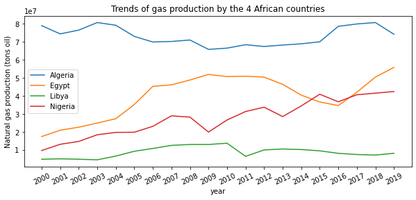

```python
#Plot dynamic of each country production
plt.figure(figsize=(10, 4))
sns.lineplot(x='year', y='natural_gas', hue='country', data=df_african_gas)
plt.xticks(rotation=25)
plt.legend()
plt.ylabel("Natural gas production (tons oil)")
plt.title("Trends of gas production by the 4 African countries")
plt.show()
```

The dynamics of production in Algeria (the largest producer) and Libya (smallest producer) are relatively stable over time.\ In contrast, gas production in Nigeria and Egypt has increased over the years.

#### 4. The Sustainable Development Index (SDI) measures the ecological efficiency of nations in terms of human development

##### a) Is there a link between each of these 3 variables and the sustainable development index

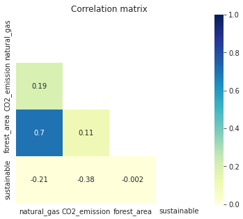

```python
#This code is to calculate correlation
#between variable of interest

correlation = round(df_final.corr(), 3)
mask = np.zeros_like(correlation)
mask[np.triu_indices_from(mask)] = True
with sns.axes_style("white"):
    f, ax = plt.subplots(figsize=(6,5))
    ax = sns.heatmap(correlation, cmap="YlGnBu", annot = True,
            mask=mask, square=True, vmin=0, vmax=1).set(title = 'Correlation matrix')
```

Based on the results, it seems that there is not a strong relationship between each of the 3 variables and the SDI

## Conclusions

In this analysis, we notice a clear decrease in the world's forests in the last few years. In contrast, gas production continues to increase.\ By definition the SDI is related to the environmental concept, we did not observe any link between the SDI and the other environmental parameters.

## Limitation

For other perspectives, it would be interesting to add data on populations, life expectancy, and GDP to better understand these relationships with sustainable developpement index. This addition of more data will make some of the previous results more meaningful.